# Projekt z przedmiotu Automatyczna Analiza obrazu

Author

Anna Kaczmarek

[figure not shown]

Celem projektu jest budowa sieci potrafiącej na podstawie zdjęć pokemonów przwidzieć typ ich ataku. Wygląd pokemonów jest jednym z kluczowych czynników, które przyciągają uwagę miłośników kreskówki. Zastosowanie uczenia maszynowego i technik analizy obrazu do identyfikacji typu pokemonów na podstawie ich wyglądu może być fascynującym wyzwaniem i interesującym projektem, ponieważ pokemony to niezwykle zróżnicowana grupa stworzeń, które występują w wielu różnych kształtach, rozmiarach i kolorach. Różnorodność wyglądu pokemonów tego samego typu jest spowodowana zarówno różnicami genetycznymi, jak i różnymi środowiskami, w których żyją, co może wprowadzać pewne trudności w dokładnej predykcji. Istnieje wiele wyjątków, gdy dwa pokemony tego samego typu mogą różnić się wyglądem z powodu czynników takich jak ewolucja, różnice regionalne lub warianty kolorystyczne.

Zbiór, który bedziemy wykorzystywać pochodzi z witryny [kaggle](https://www.kaggle.com/datasets/vishalsubbiah/pokemon-images-and-types) i zawiera podpisane zdjęcia 809 pokemonów. Dodatkowo mamy plik csv zawierający nazwę oraz typ ataku każdego z nich i będzie to nasza zmienna wynikowa.

Wyświetlimy kilka wierszy zbioru.

| Name | Type |
| --- | --- |
| bulbasaur | Grass |
| ivysaur | Grass |
| venusaur | Grass |
| charmander | Fire |
| charmeleon | Fire |
| charizard | Fire |
| squirtle | Water |
| wartortle | Water |
| blastoise | Water |
| caterpie | Bug |

Narysujemy kilka oraz wyświetlimy jak prezentuje się rozkład w zależności od ich typu, czyli jak dużo jest każdego rodzaju pokemonów.

[figure not shown]

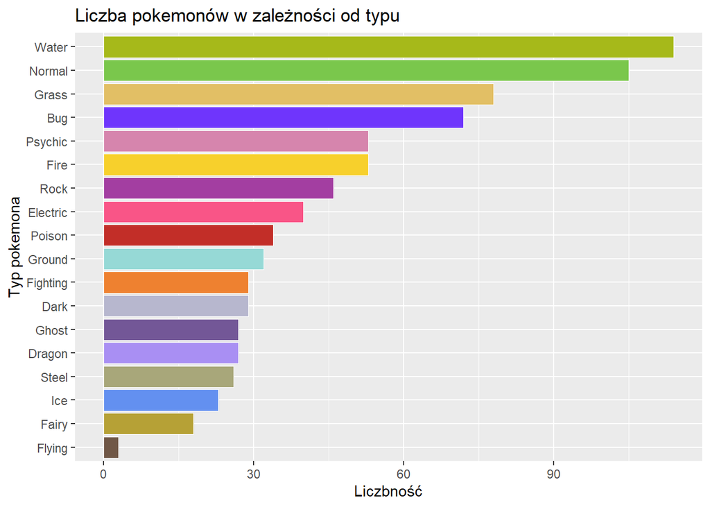

Wszystkich typów jest 18 jednak jak widzimy nasz zbiór jest bardzo mocno niezbalansowany, wodnych pokemonów w porównaniu do latających jest aż 38 razy więcej. Z tego też powodu usuniemy najpierw dwie najmniej liczne kategorie `flying` oraz `fairy` i będziemy zajmować się szesnastoma.

# Przygotowanie danych

Zanim przejdziemy do budowy modelu musimy prygotować nasze dane, w tym celu stworzymy jedną tabele zawierającą ścieżke do zdjęcia każdego pokemona, odpowiedni type jego ataku, a dodatkowo zrobimy kolumne `code` zawierającą typ ataku, ale jako zmienna numeryczna.

| filepath | type | code |
| --- | --- | --- |
| C:/Users/annak/OneDrive/Pulpit/VI SEMESTR/AUTOMATYCZNA ANALIZA OBRAZU/images/abomasnow.png | Grass | 1 |
| C:/Users/annak/OneDrive/Pulpit/VI SEMESTR/AUTOMATYCZNA ANALIZA OBRAZU/images/alomomola.png | Water | 2 |
| C:/Users/annak/OneDrive/Pulpit/VI SEMESTR/AUTOMATYCZNA ANALIZA OBRAZU/images/cherubi.png | Grass | 1 |
| C:/Users/annak/OneDrive/Pulpit/VI SEMESTR/AUTOMATYCZNA ANALIZA OBRAZU/images/chesnaught.png | Grass | 1 |
| C:/Users/annak/OneDrive/Pulpit/VI SEMESTR/AUTOMATYCZNA ANALIZA OBRAZU/images/chespin.png | Grass | 1 |
| C:/Users/annak/OneDrive/Pulpit/VI SEMESTR/AUTOMATYCZNA ANALIZA OBRAZU/images/chikorita.png | Grass | 1 |
| C:/Users/annak/OneDrive/Pulpit/VI SEMESTR/AUTOMATYCZNA ANALIZA OBRAZU/images/chimchar.png | Fire | 6 |
| C:/Users/annak/OneDrive/Pulpit/VI SEMESTR/AUTOMATYCZNA ANALIZA OBRAZU/images/chimecho.png | Psychic | 5 |
| C:/Users/annak/OneDrive/Pulpit/VI SEMESTR/AUTOMATYCZNA ANALIZA OBRAZU/images/chinchou.png | Water | 2 |
| C:/Users/annak/OneDrive/Pulpit/VI SEMESTR/AUTOMATYCZNA ANALIZA OBRAZU/images/chingling.png | Psychic | 5 |

# Podział na zbiory oraz przygotowanie obrazów

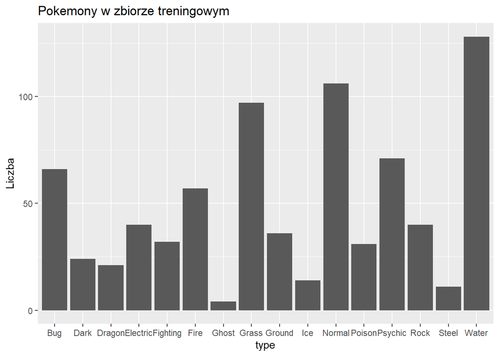

[figure not shown]

# Budowa modelu

Poniżej widzimy strukturę sieci. Składa się ona z czterech rozszerzających się warstw konwolucyjnych, trzech max_pooling oraz dwóch gęstych. Liczba całkowita parametrów wynosi $13,179,088$.

```
Model: "sequential"
________________________________________________________________________________
 Layer (type)                       Output Shape                    Param #
================================================================================
 conv2d_3 (Conv2D)                  (None, 114, 114, 64)            12608
 max_pooling2d_2 (MaxPooling2D)     (None, 57, 57, 64)              0
 conv2d_2 (Conv2D)                  (None, 51, 51, 128)             401536
 max_pooling2d_1 (MaxPooling2D)     (None, 25, 25, 128)             0
 conv2d_1 (Conv2D)                  (None, 19, 19, 256)             1605888
 max_pooling2d (MaxPooling2D)       (None, 9, 9, 256)               0
 conv2d (Conv2D)                    (None, 3, 3, 512)               6423040
 flatten (Flatten)                  (None, 4608)                    0
 dense_1 (Dense)                    (None, 1024)                    4719616
 dense (Dense)                      (None, 16)                      16400
================================================================================
Total params: 13,179,088
Trainable params: 13,179,088
Non-trainable params: 0
________________________________________________________________________________
```

[figure not shown]